# Бизнес-показатели маркетплейса

**Дата:** 01.10.2025

**Цель исследования:** на основе набора данных построение целостной картины бизнеса:

- обзор ключевых метрик,
- оценка монетизации (как продукт зарабатывает деньги),
- оценка юнит-экономики (насколько это прибыльно в расчете на единицу клиента или товара),
- поиск инсайтов и точек роста для бизнеса.

## Вводные по кейсу

Описание данных

Таблица `Users`

| Поле | Описание |
| --- | --- |
| `user_id` | Уникальный идентификатор пользователя. |
| `registration_date` | Дата регистрации пользователя. |
| `age` | Возраст пользователя. |
| `gender` | Пол. |
| `region` | Регион. |
| `acq_channel` | Канал привлечения. |
| `buyer_segment` | Сегмент покупателя. |
| `cohort_week` | Неделя привлечения. |
| `cohort_month` | Месяц привлечения. |

Таблица `Events`

| Поле | Описание |
| --- | --- |
| `event_id` | Уникальный идентификатор события. |
| `user_id` | Идентификатор пользователя. |
| `event_date` | Дата события. |
| `event_type` | Тип события. |
| `os` | Операционная система. |
| `device` | Тип устройства. |
| `product_name` | Наименование товара, к которому относится событие (если применимо). |
| `event_week` | Неделя события. |
| `event_month` | Месяц события . |

Таблица `Orders`

| Поле | Описание |
| --- | --- |
| `order_id` | Уникальный идентификатор заказа. |
| `user_id` | Идентификатор пользователя, который сделал заказ |
| `order_date` | Дата и время оформления заказа. |
| `product_name` | Наименование товара. |
| `quantity` | Количество единиц товара в заказе. |
| `unit_price` | Цена за одну единицу товара. |
| `total_price` | Итоговая сумма заказа. |
| `category_name` | Наименование категории товара. |
| `order_week` | Неделя заказа. |
| `order_month` | Месяц заказа. |

Таблица `Campaign_costs`

| Поле | Описание |
| --- | --- |
| `acq_channel` | Канал привлечения. |
| `spend_month` | Месяц, в который был потрачен бюджет (отражает период, в котором были привлечены пользователи) |
| `budget` | Маркетинговый бюджет (в денежном выражении), потраченный на данный канал в указанном месяце. |

Описание событий

| Событие | Описание |
| --- | --- |
| `page_view` | Открытие любой страницы сайта или приложения пользователем. |
| `product_view` | Просмотр страницы конкретного товара. |
| `product_click` | Клик по товару (например, из списка товаров или на баннере). |
| `add_to_cart` | Добавление товара в корзину. |
| `remove_from_cart` | Удаление товара из корзины. |
| `search` | Выполнение поиска по сайту или приложению. |
| `filter_apply` | Применение фильтра (например, по цене, бренду, категории). |
| `checkout_start` | Начало оформления заказа (переход к оформлению корзины). |
| `checkout_complete` | Завершение оформления заказа (не гарантирует покупку, покупка зависит от факта оплаты). |
| `user_login` | Вход пользователя в личный кабинет или аккаунт. |
| `user_logout` | Выход пользователя из аккаунта. |
| `wishlist_add` | Добавление товара в список желаемого (wishlist). |
| `category_view` | Просмотр страницы категории товаров. |
| `banner_click` | Клик по рекламному баннеру на сайте или в приложении. |
| `promo_view` | Просмотр промо-акции или специального предложения. |

Выручка маркетплейса = 5% от total_price

## План работы

1. Загрузка библиотек
2. Загрузка и предобработка данных
3. Построение дерева метрик
4. Обзор ключевых метрик
5. Оценка метрик монетизации и юнит-экономики
6. Поиск инсайтов, точек роста и сегментация
7. Выводы

## Загрузка библиотек

```python
import pandas as pd
```

```python
# Загружаем библиотеки для визуализации данных
import matplotlib.pyplot as plt
import matplotlib.colors as mcolors
import seaborn as sns
```

```python
from datetime import date, datetime
```

```python
import numpy as np
```

```python
import math
```

```python
# Уменьшение разрешения DPI для графиков
plt.rcParams['figure.dpi'] = 72
```

## Загрузка данных и их предобработка

```python
path = 'datasets/'
```

### df_users - пользователи

```python
try:
    df_users = pd.read_csv(path + 'pa_marketplace_users.csv', parse_dates=['registration_date','cohort_week', 'cohort_month'])
    display(f'Файл успешно загружен  в датафрейм df_users')
except:
    display(f'Ошибка при загрузке файла')
```

```
'Файл успешно загружен  в датафрейм df_users'
```

```python
display(df_users.info())
```

```
<class 'pandas.core.frame.DataFrame'>
RangeIndex: 44151 entries, 0 to 44150
Data columns (total 9 columns):
 #   Column             Non-Null Count  Dtype
---  ------             --------------  -----
 0   user_id            44151 non-null  int64
 1   registration_date  44151 non-null  datetime64[ns]
 2   age                44151 non-null  int64
 3   gender             44151 non-null  object
 4   region             44151 non-null  object
 5   acq_channel        44151 non-null  object
 6   buyer_segment      44151 non-null  object
 7   cohort_week        44151 non-null  datetime64[ns]
 8   cohort_month       44151 non-null  datetime64[ns]
dtypes: datetime64[ns](3), int64(2), object(4)
memory usage: 3.0+ MB
```

```
None
```

```python
display(df_users.head())
```

|  | user_id | registration_date | age | gender | region | acq_channel | buyer_segment | cohort_week | cohort_month |
| --- | --- | --- | --- | --- | --- | --- | --- | --- | --- |
| 0 | 1 | 2024-01-01 00:47:00 | 35 | M | Москва | Google Ads | regular | 2024-01-01 | 2024-01-01 |
| 1 | 2 | 2024-01-01 19:01:00 | 53 | M | Москва | Email Marketing | rare | 2024-01-01 | 2024-01-01 |
| 2 | 3 | 2024-01-01 04:13:00 | 66 | F | Санкт-Петербург | Google Ads | regular | 2024-01-01 | 2024-01-01 |
| 3 | 4 | 2024-01-01 17:18:00 | 58 | M | Краснодар | Affiliate | one_time | 2024-01-01 | 2024-01-01 |
| 4 | 5 | 2024-01-01 08:29:00 | 58 | F | Другие регионы | Google Ads | regular | 2024-01-01 | 2024-01-01 |

```python
#Проверим на наличие явных дубликатов в данных по всем столбцам
display(f'Явных дубликатов по всем столбцам: {df_users.duplicated().sum()}.\
        Это {df_users.duplicated().sum()/df_users.shape[0]} %')
```

```
'Явных дубликатов по всем столбцам: 0.        Это 0.0 %'
```

```python
# Проверим на дубликаты по ID пользователя
display(f'Дублирующихся ID пользователя: {df_users.duplicated(subset=["user_id"]).sum()}')
```

```
'Дублирующихся ID пользователя: 0'
```

```python
# Уберем время из даты регистрации
df_users['registration_date'] = pd.to_datetime(df_users['registration_date'].dt.date)
```

```python
display(f'Интервал дат "registration_date": "{df_users["registration_date"].dt.date.min()} - {df_users["registration_date"].dt.date.max()}')
display(f'Интервал дат "cohort_week": "{df_users["cohort_week"].dt.date.min()} - {df_users["cohort_week"].dt.date.max()}')
display(f'Интервал дат "cohort_month": "{df_users["cohort_month"].dt.date.min()} - {df_users["cohort_month"].dt.date.max()}')
```

```
'Интервал дат "registration_date": "2024-01-01 - 2024-12-31'
```

```
'Интервал дат "cohort_week": "2024-01-01 - 2024-12-30'
```

```
'Интервал дат "cohort_month": "2024-01-01 - 2024-12-01'
```

```python
display(df_users['gender'].unique())
```

```
array(['M', 'F'], dtype=object)
```

```python
display(df_users['age'].describe())
```

```
count    44151.000000
mean        43.993409
std         15.293834
min         18.000000
25%         31.000000
50%         44.000000
75%         57.000000
max         70.000000
Name: age, dtype: float64
```

```python
display(df_users['region'].unique())
```

```
array(['Москва', 'Санкт-Петербург', 'Краснодар', 'Другие регионы',
       'Нижний Новгород', 'Екатеринбург', 'Московская область',
       'Новосибирск', 'Ростов-на-Дону'], dtype=object)
```

```python
display(df_users['acq_channel'].unique())
```

```
array(['Google Ads', 'Email Marketing', 'Affiliate', 'SEO',
       'Social Media', 'TikTok'], dtype=object)
```

```python
display(df_users['buyer_segment'].unique())
```

```
array(['regular', 'rare', 'one_time', 'medium'], dtype=object)
```

### df_events - cобытия

```python
try:
    df_events = pd.read_csv(path + 'pa_marketplace_events.csv', parse_dates=["event_date","event_week", "event_month"])
    display(f'Файл успешно загружен  в датафрейм df_events')
except:
    display(f'Ошибка при загрузке файла')
```

```
'Файл успешно загружен  в датафрейм df_events'
```

```python
display(df_events.info())
```

```
<class 'pandas.core.frame.DataFrame'>
RangeIndex: 785859 entries, 0 to 785858
Data columns (total 9 columns):
 #   Column        Non-Null Count   Dtype
---  ------        --------------   -----
 0   event_id      785859 non-null  int64
 1   user_id       785859 non-null  int64
 2   event_date    785859 non-null  datetime64[ns]
 3   event_type    785859 non-null  object
 4   os            785859 non-null  object
 5   device        785859 non-null  object
 6   product_name  385740 non-null  object
 7   event_week    785859 non-null  datetime64[ns]
 8   event_month   785859 non-null  datetime64[ns]
dtypes: datetime64[ns](3), int64(2), object(4)
memory usage: 54.0+ MB
```

```
None
```

```python
display(df_events.head())
```

|  | event_id | user_id | event_date | event_type | os | device | product_name | event_week | event_month |
| --- | --- | --- | --- | --- | --- | --- | --- | --- | --- |
| 0 | 3132 | 100 | 2024-01-01 | page_view | iOS | mobile | NaN | 2024-01-01 | 2024-01-01 |
| 1 | 3133 | 100 | 2024-01-01 | product_view | iOS | mobile | Шорты для тренировок | 2024-01-01 | 2024-01-01 |
| 2 | 3134 | 100 | 2024-01-01 | product_click | iOS | mobile | Куртка детская | 2024-01-01 | 2024-01-01 |
| 3 | 3135 | 100 | 2024-01-01 | add_to_cart | iOS | mobile | Балетки классические | 2024-01-01 | 2024-01-01 |
| 4 | 3136 | 100 | 2024-01-01 | checkout_start | iOS | mobile | NaN | 2024-01-01 | 2024-01-01 |

```python
display(df_events.isna().sum())
```

```
event_id             0
user_id              0
event_date           0
event_type           0
os                   0
device               0
product_name    400119
event_week           0
event_month          0
dtype: int64
```

```python
#Проверим на наличие явных дубликатов в данных по всем столбцам
display(f'Явных дубликатов по всем столбцам: {df_events.duplicated().sum()}.\
        Это {df_events.duplicated().sum()/df_events.shape[0]} %')
```

```
'Явных дубликатов по всем столбцам: 0.        Это 0.0 %'
```

```python
# Проверим на дубликаты по ID события
display(f'Дублирующихся ID событий {df_events.duplicated(subset=["event_id"]).sum()}')
```

```
'Дублирующихся ID событий 0'
```

```python
display(f'Интервал дат "event_date": "{df_events["event_date"].dt.date.min()} - {df_events["event_date"].dt.date.max()}')
display(f'Интервал дат "event_week": "{df_events["event_week"].dt.date.min()} - {df_events["event_week"].dt.date.max()}')
display(f'Интервал дат "event_month": "{df_events["event_month"].dt.date.min()} - {df_events["event_month"].dt.date.max()}')
```

```
'Интервал дат "event_date": "2024-01-01 - 2024-12-31'
```

```
'Интервал дат "event_week": "2024-01-01 - 2024-12-30'
```

```
'Интервал дат "event_month": "2024-01-01 - 2024-12-01'
```

```python
display(df_events['event_type'].unique())
```

```
array(['page_view', 'product_view', 'product_click', 'add_to_cart',
       'checkout_start', 'checkout_complete', 'user_logout', 'search',
       'category_view', 'filter_apply', 'promo_view', 'wishlist_add',
       'user_login', 'banner_click', 'remove_from_cart'], dtype=object)
```

```python
display(df_events['os'].unique())
```

```
array(['iOS', 'Windows', 'macOS', 'Android'], dtype=object)
```

```python
display(df_events['device'].unique())
```

```
array(['mobile', 'desktop', 'tablet'], dtype=object)
```

```python
display(df_events['product_name'].nunique())
```

```
200
```

### df_orders - заказы

```python
try:
#пробуем загрузить
    df_orders = pd.read_csv(path + 'pa_marketplace_orders.csv', parse_dates=['order_date', 'order_week', 'order_month'])
    display(f'Файл успешно загружен  в датафрейм df_orders')
except:
    # если не получилось
    display(f'Ошибка при загрузке файла')
```

```
'Файл успешно загружен  в датафрейм df_orders'
```

```python
display(df_orders.info())
```

```
<class 'pandas.core.frame.DataFrame'>
RangeIndex: 31357 entries, 0 to 31356
Data columns (total 10 columns):
 #   Column         Non-Null Count  Dtype
---  ------         --------------  -----
 0   order_id       31357 non-null  int64
 1   user_id        31357 non-null  int64
 2   order_date     31357 non-null  datetime64[ns]
 3   product_name   31357 non-null  object
 4   quantity       31357 non-null  int64
 5   unit_price     31357 non-null  float64
 6   total_price    31357 non-null  float64
 7   category_name  31357 non-null  object
 8   order_week     31357 non-null  datetime64[ns]
 9   order_month    31357 non-null  datetime64[ns]
dtypes: datetime64[ns](3), float64(2), int64(3), object(2)
memory usage: 2.4+ MB
```

```
None
```

```python
display(df_orders.head())
```

|  | order_id | user_id | order_date | product_name | quantity | unit_price | total_price | category_name | order_week | order_month |
| --- | --- | --- | --- | --- | --- | --- | --- | --- | --- | --- |
| 0 | 1 | 3 | 2024-01-19 01:52:52 | Шуруповерт | 2 | 5539.13 | 11078.26 | Инструменты и садовый инвентарь | 2024-01-15 | 2024-01-01 |
| 1 | 2 | 3 | 2024-01-19 01:52:52 | Молоток слесарный | 1 | 11340.38 | 11340.38 | Инструменты и садовый инвентарь | 2024-01-15 | 2024-01-01 |
| 2 | 3 | 3 | 2024-01-19 01:52:52 | Секатор садовый | 2 | 10892.09 | 21784.18 | Инструменты и садовый инвентарь | 2024-01-15 | 2024-01-01 |
| 3 | 4 | 3 | 2024-01-25 13:59:38 | Шуруповерт | 2 | 5539.13 | 11078.26 | Инструменты и садовый инвентарь | 2024-01-22 | 2024-01-01 |
| 4 | 5 | 3 | 2024-01-25 13:59:38 | Чай черный | 1 | 2099.59 | 2099.59 | Продукты питания | 2024-01-22 | 2024-01-01 |

```python
#Проверим на наличие явных дубликатов в данных по всем столбцам
display(f'Явных дубликатов по всем столбцам: {df_orders.duplicated().sum()}.\
        Это {df_orders.duplicated().sum()/df_orders.shape[0]} %')
```

```
'Явных дубликатов по всем столбцам: 0.        Это 0.0 %'
```

```python
# Проверим на дубликаты по ID заказа
display(f'Дублирующихся ID заказа: {df_orders.duplicated(subset=["order_id"]).sum()}')
```

```
'Дублирующихся ID заказа: 0'
```

```python
display(f'Интервал дат "order_date": "{df_orders["order_date"].dt.date.min()} - {df_orders["order_date"].dt.date.max()}')
display(f'Интервал дат "order_week": "{df_orders["order_week"].dt.date.min()} - {df_orders["order_week"].dt.date.max()}')
display(f'Интервал дат "order_month": "{df_orders["order_month"].dt.date.min()} - {df_orders["order_month"].dt.date.max()}')
```

```
'Интервал дат "order_date": "2024-01-01 - 2024-12-31'
```

```
'Интервал дат "order_week": "2024-01-01 - 2024-12-30'
```

```
'Интервал дат "order_month": "2024-01-01 - 2024-12-01'
```

```python
df_orders['order_date'] = pd.to_datetime(df_orders['order_date'].dt.date)
```

```python
display(df_orders['quantity'].describe())
```

```
count    31357.000000
mean         2.006857
std          0.820073
min          1.000000
25%          1.000000
50%          2.000000
75%          3.000000
max          3.000000
Name: quantity, dtype: float64
```

```python
display(df_orders['unit_price'].describe())
```

```
count    31357.000000
mean      6986.909334
std       8170.131920
min        339.000000
25%       2155.370000
50%       4406.630000
75%       9395.950000
max      63932.380000
Name: unit_price, dtype: float64
```

```python
display(df_orders['total_price'].describe())
```

```
count     31357.000000
mean      14030.175560
std       18667.398146
min         339.000000
25%        3776.740000
50%        7554.640000
75%       17657.460000
max      191797.140000
Name: total_price, dtype: float64
```

```python
# Добавим столбец - "Выручка маркетплейса" = 5% от суммы заказа
df_orders['Revenue_mp'] = round(df_orders['total_price']*0.05,2)
```

```python
display(df_orders['Revenue_mp'].describe())
```

```
count    31357.000000
mean       701.508817
std        933.369876
min         16.950000
25%        188.840000
50%        377.730000
75%        882.870000
max       9589.860000
Name: Revenue_mp, dtype: float64
```

```python
display(df_orders['product_name'].nunique())
```

```
200
```

```python
display(df_orders['category_name'].nunique())
```

```
25
```

### df_campaign - рекламные компании

```python
try:
    df_campaign = pd.read_csv(path + 'pa_marketplace_campaign_costs.csv', parse_dates=["spend_month"])
    display(f'Файл успешно загружен  в датафрейм df_campaign')
except:
    display(f'Ошибка при загрузке файла')
```

```
'Файл успешно загружен  в датафрейм df_campaign'
```

```python
display(df_campaign.info())
```

```
<class 'pandas.core.frame.DataFrame'>
RangeIndex: 88 entries, 0 to 87
Data columns (total 4 columns):
 #   Column       Non-Null Count  Dtype
---  ------       --------------  -----
 0   Unnamed: 0   88 non-null     int64
 1   acq_channel  88 non-null     object
 2   spend_month  88 non-null     datetime64[ns]
 3   budget       88 non-null     float64
dtypes: datetime64[ns](1), float64(1), int64(1), object(1)
memory usage: 2.9+ KB
```

```
None
```

```python
display(df_campaign.head())
```

|  | Unnamed: 0 | acq_channel | spend_month | budget |
| --- | --- | --- | --- | --- |
| 0 | 0 | Affiliate | 2024-01-01 | 179343.3875 |
| 1 | 1 | Affiliate | 2024-02-01 | 175488.4875 |
| 2 | 2 | Affiliate | 2024-03-01 | 164543.4750 |
| 3 | 3 | Affiliate | 2024-04-01 | 186869.9750 |
| 4 | 4 | Affiliate | 2024-05-01 | 166443.7750 |

```python
# Проверим на дубликаты по столбцу "Unnamed: 0"
display(f'Дублей по Unnamed: 0: {df_campaign.duplicated(subset=["Unnamed: 0"]).sum()}')
```

```
'Дублей по Unnamed: 0: 0'
```

Т.к. в связь между df_users и df_campaign осуществляется по столбцам acq_channel + дата/месяц привлечения, то столбец "Unnamed: 0" можно удалить за ненадобностью.

```python
# Удаляем "Unnamed: 0"
df_campaign = df_campaign.drop("Unnamed: 0", axis=1)
```

```python
# Проверим на дубликаты "acq_channel"+"spend_month"
display(f'Дублей по "acq_channel"+"spend_month": {df_campaign.duplicated(subset=["acq_channel", "spend_month"]).sum()}')
```

```
'Дублей по "acq_channel"+"spend_month": 0'
```

```python
display(f'Интервал дат "spend_month": "{df_campaign["spend_month"].dt.date.min()} - {df_campaign["spend_month"].dt.date.max()}')
```

```
'Интервал дат "spend_month": "2024-01-01 - 2025-01-01'
```

```python
# Ограничим рекламные кампании 2024-м годом
df_campaign = df_campaign.loc[df_campaign['spend_month'].dt.year == 2024]
```

```python
display(f'Список рекламных кампаний: {df_campaign["acq_channel"].unique()}')
```

```
"Список рекламных кампаний: ['Affiliate' 'Direct' 'Email Marketing' 'Social Media' 'Google Ads' 'SEO'\n 'TikTok']"
```

```python
display(df_campaign.describe().round(2))
```

|  | spend_month | budget |
| --- | --- | --- |
| count | 82 | 82.00 |
| mean | 2024-06-12 14:38:02.926829312 | 216612.33 |
| min | 2024-01-01 00:00:00 | 6674.10 |
| 25% | 2024-03-08 18:00:00 | 43741.83 |
| 50% | 2024-06-01 00:00:00 | 120466.12 |
| 75% | 2024-09-01 00:00:00 | 174527.33 |
| max | 2024-12-01 00:00:00 | 1533683.38 |
| std | NaN | 325933.51 |

**Вывод:** Данные загружены. Данные соответствуют заявленным и содержат информацию о покупках и событиях пользователей на маркетплейсе, а также рекламных компаниях по привлечению пользователей.. Преобразоваение столбцов, содержащих даты не требуется, т.к. данные, содержащие дату и время, преобразованы на этапе выгрузки файлов.

## Обзор ключевых метрик

### Дерево метрик

Ниже приложен слайд с деревом метрик.

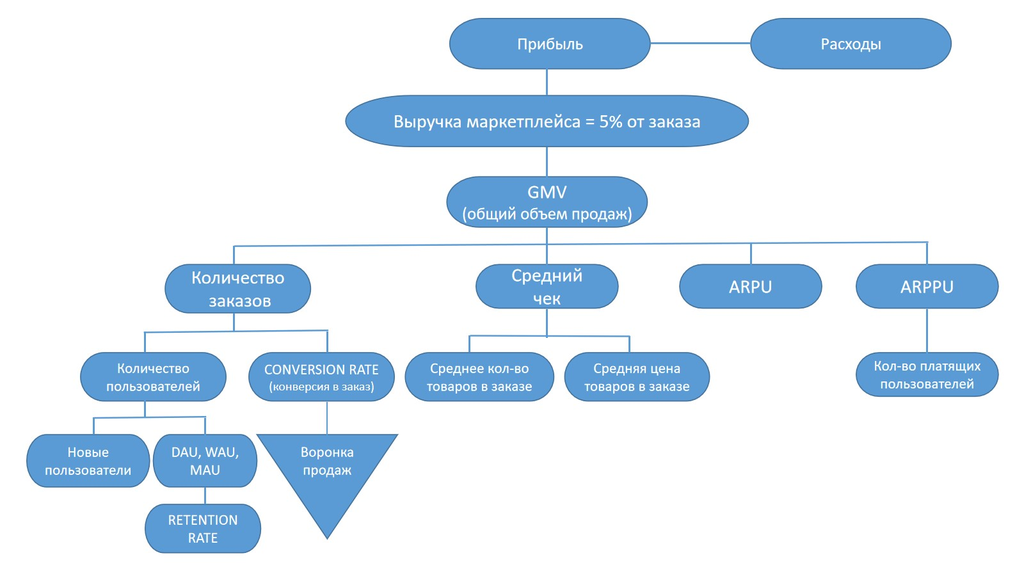

### GMV, выручка маркетплейса

Посчитаем GMV (Gross Merchandise Value) т.к. выручка маркетплеса напрямую зависит от общего объема продаж.

```python
# Группируем по месяцам заказа
GMV_month = df_orders.groupby('order_month')['total_price'].sum().reset_index()
```

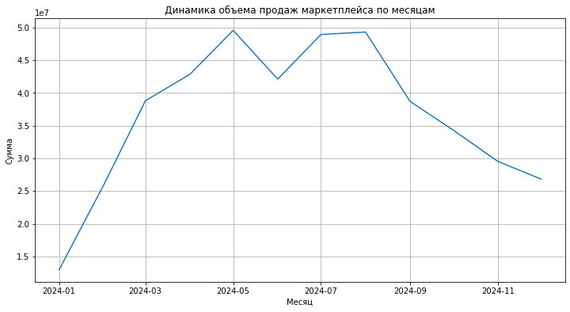

```python
# Визуализируем Revenue
plt.subplots(figsize=(12,6))
plt.plot(GMV_month['order_month'], GMV_month['total_price'])
plt.title('Динамика объема продаж маркетплейса по месяцам')
plt.xlabel('Месяц')
plt.ylabel('Сумма')
plt.grid()
plt.show()
```

**Вывод:** Объем продаж рос хорошими темпами с начала года до мая, затем незначительно упал в июне, стабилизировался в июле-августе. С сентября зафиксировано значительное падение продаж, продолжающееся до конца рассматриваемого периода, что говорит о негативных тенденциях.

### Расходы на привлечение пользователей

```python
report = df_campaign.groupby('spend_month')['budget'].sum().reset_index()
```

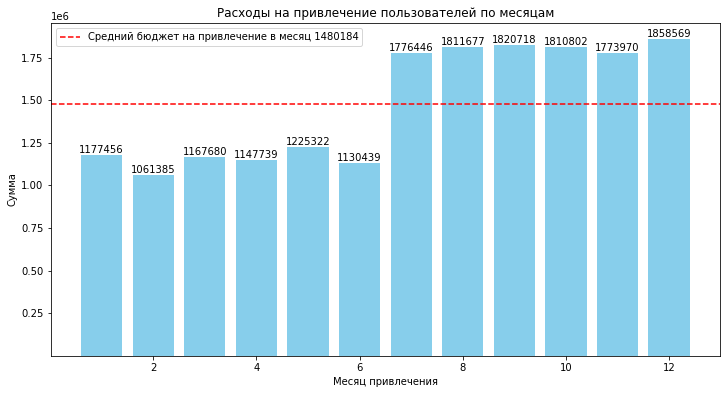

```python
# Визуализируем
plt.figure(figsize=(12,6))

bars = plt.bar(report['spend_month'].dt.month, report['budget'].astype('int'), width = 0.8, color='skyblue')
plt.ylim(300)

for bar in bars:
    yval = bar.get_height() # высота столбца=значение
    plt.text(bar.get_x() + bar.get_width()/2, yval+1, f'{yval}', verticalalignment='bottom', horizontalalignment='center')

plt.axhline(report['budget'].mean(), color='red', linestyle='--',
               label=f'Средний бюджет на привлечение в месяц {report["budget"].mean().astype("int")}')
plt.title('Расходы на привлечение пользователей по месяцам')
plt.xlabel('Месяц привлечения')
plt.legend()
plt.ylabel('Сумма')
plt.show()
```

**Вывод:** Наблюдаем значительное повышение расходов на привлечение клиентов с июля.

### Количество заказов

```python
# Группируем по месяцу заказа и считаем общее количество заказов и их сумму
orders_month = df_orders.groupby('order_month').agg({'total_price': 'sum',
                                                     'quantity': 'sum',
                                                     'unit_price': 'mean',
                                                     'order_id' :'count'}).reset_index()
```

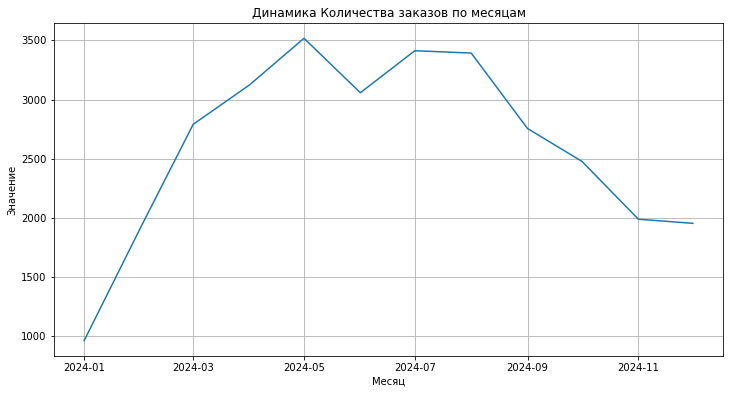

```python
# Визуализируем
plt.subplots(figsize=(12,6))
plt.plot(orders_month['order_month'], orders_month['order_id'])
plt.title('Динамика Количества заказов по месяцам')
plt.xlabel('Месяц')
plt.ylabel('Значение')
plt.grid()
plt.show()
```

**Вывод:** Падение выручки напрямую связано с падением количества заказов, т.к. графики идентичны по форме.

### Метрики вовлеченности

##### **Динамика привлечения новых пользователей**

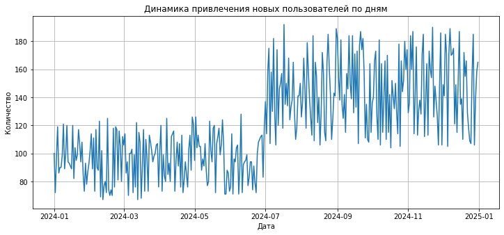

```python
# Считаем количество новых пользователей по дате регистрации
df_users_day = df_users.groupby('registration_date')['user_id'].nunique().reset_index()
df_users_day = df_users_day.rename(columns={'user_id' : 'n_users'})

# визуализируем
plt.subplots(figsize=(12,5))

plt.plot(df_users_day['registration_date'], df_users_day['n_users'])

plt.title('Динамика привлечения новых пользователей по дням')
plt.xlabel('Дата')
plt.ylabel('Количество')
#plt.xticks(rotation=45)
plt.grid()
plt.show()
```

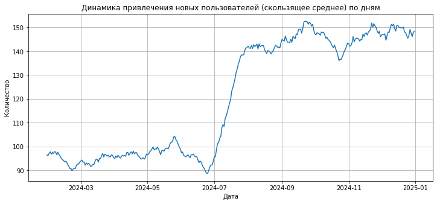

```python
# визуализируем скользящее среднее на окне в 30 дней
plt.subplots(figsize=(12,5))

plt.plot(df_users_day['registration_date'], df_users_day['n_users'].rolling(window=30).mean())

plt.title('Динамика привлечения новых пользователей (скользящее среднее) по дням')
plt.xlabel('Дата')
plt.ylabel('Количество')
#plt.xticks(rotation=45)
plt.grid()
plt.show()
```

**Вывод:** Новые пользователи приходят каждый день, но неравномерно. С июль-август наблюдаем резкий рост количества новых пользователей. Здесь проблем не наблюдаем, наоборот, новые пользователи должны были привести к увеличению выручки.

##### **DAU**

```python
# Группируем по дате события и считаем уникальных пользователей
dau_all = df_events.groupby('event_date')['user_id'].nunique().reset_index()

# Переименуем столбец 'user_id' в 'DAU'
dau_all = dau_all.rename(columns={'user_id': 'DAU'})
```

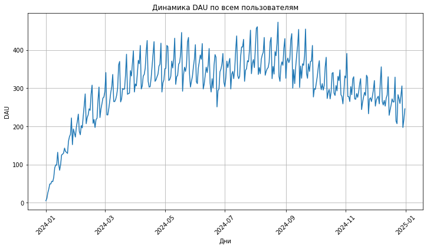

```python
# Визуализируем DAU
plt.subplots(figsize=(12,6))
plt.plot(dau_all['event_date'], dau_all['DAU'])
plt.title('Динамика DAU по всем пользователям')
plt.xlabel('Дни')
plt.ylabel('DAU')
plt.xticks(rotation=45)
plt.grid()
plt.show()
```

**Вывод**: Несмотря на недельные колебания, пользователи заходят на маркетплейс каждый день во всем периоде наблюдения. Небольшое снижение: июнь-июль и с октября.

##### **WAU**

```python
wau_all = df_events.loc[df_events['event_week'] <= '2024-12-01']
```

```python
# Группируем по дате недели события и считаем уникальных пользователей
wau_all = wau_all.groupby('event_week')['user_id'].nunique().reset_index()
```

```python
#переименуем столбец 'user_id' в 'WAU'
wau_all = wau_all.rename(columns={'user_id': 'WAU'})
```

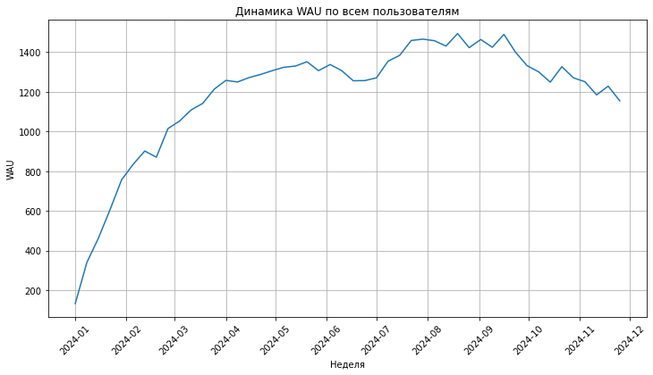

```python
# Визуализируем WAU
plt.subplots(figsize=(12,6))
plt.plot(wau_all['event_week'], wau_all['WAU'])
plt.title('Динамика WAU по всем пользователям')
plt.xlabel('Неделя')
plt.ylabel('WAU')
plt.xticks(rotation=45)
plt.grid()
plt.show()
```

##### **MAU**

```python
# Группируем по месяцу события и считаем уникальных пользователей
mau_all = df_events.groupby('event_month')['user_id'].nunique().reset_index()
```

```python
#переименуем столбец 'user_id' в 'MAU'
mau_all = mau_all.rename(columns={'user_id': 'MAU'})
```

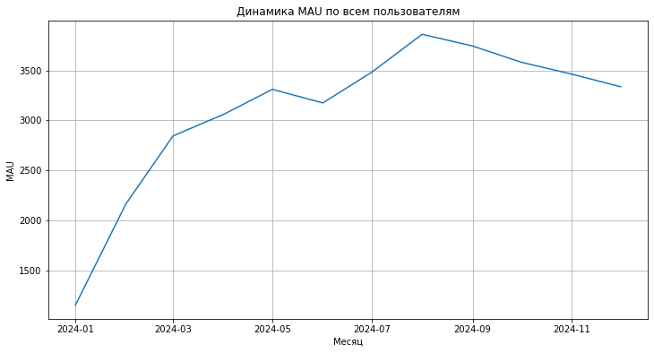

```python
# Визуализируем MAU
plt.subplots(figsize=(12,6))
plt.plot(mau_all['event_month'], mau_all['MAU'])
plt.title('Динамика MAU по всем пользователям')
plt.xlabel('Месяц')
plt.ylabel('MAU')
plt.grid()
plt.show()
```

### Retantion Rate по событиям

Считаем классический показатель, т.к. маркетплейсом пользуются часто, как правило, нет отложенного спроса. Посчитаем коэффициент удержания по событиям - насколько пользователям интересен маркетплейс. Пользователи могут заходить на маркетплейс, просматривать, сравнивать цены и не сразу покупать. Рассчитаем по месяцам за год.

```python
# Определяем дату первого события пользователя
# Отсортируем события по пользователю и месяцем события
df_events = df_events.sort_values(by=['user_id', 'event_month'])
```

```python
# Удалим дублирующиеся записи чтобы получить список с месяцем первого события, оставляем первую запись.
users_first_month = df_events[['user_id','event_month']].drop_duplicates(subset=['user_id'], keep ='first')
```

```python
# переименуем столбец
users_first_month = users_first_month.rename(columns = {'event_month': 'first_event_month'})
```

```python
# Объединим со всеми событиями, добавив первую дату в события
users_events_month = pd.merge(df_events, users_first_month, on='user_id', how='left')
```

```python
# Оставим только пользователей с первым событием в начале года
df_RR_event = users_events_month.loc[users_events_month['first_event_month'] == '2024-01-01']
```

```python
df_RR_event = df_RR_event.groupby('event_month')['user_id'].nunique()
```

```python
df_RR_event = df_RR_event.div(df_RR_event.iloc[0], axis=0)
```

```python
#df_RR_event = df_RR_event.div(df_RR_event[0], axis=0)
```

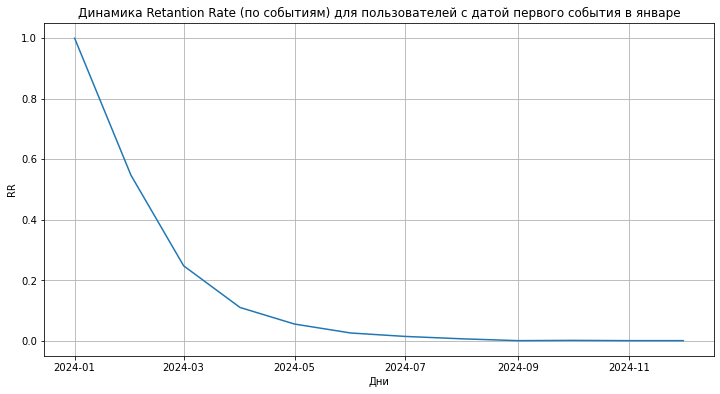

```python
# Визуализируем RR по событиям
plt.subplots(figsize=(12,6))
plt.plot(df_RR_event.index, df_RR_event.values)
plt.title('Динамика Retantion Rate (по событиям) для пользователей с датой первого события в январе')
plt.xlabel('Дни')
plt.ylabel('RR')
plt.grid()
plt.show()
```

**Вывод:** Показатель резко падает к 3-му месяцу, и, в дальнейшем, практически до 0 за 8 месяцев. Это негативная тенденция.

### Retantion Rate по заказам

Рассчитаем показатель: Какая доля пользователей, совершивших первую покупку, делает повторные покупки, по месяцам.

Месяц первой покупки считаем от первого заказа, а не от когорты, т.к. спрос может быть отложенным и покупка может быть не в первый месяц после регистрации, а позже.

```python
# Отсортируем заказы по пользователю и месяцу заказа
df_orders = df_orders.sort_values(by=['user_id', 'order_month'])
```

```python
# Удалим дублирующиеся записи чтобы получить список с месяцем первого заказа, оставляем первую запись.
users_first_month = df_orders[['user_id','order_month']].drop_duplicates(subset=['user_id'], keep ='first')
```

```python
# Отсортируем заказы по пользователю и месяцу заказа
df_orders = df_orders.sort_values(by=['user_id', 'order_month'])
```

```python
# переименуем столбец
users_first_month = users_first_month.rename(columns = {'order_month': 'first_order_month'})
```

```python
# Объединим со всеми заказами, добавив первую дату заказа
users_orders_month = pd.merge(df_orders, users_first_month, on='user_id', how='left')
```

```python
# Оставим только пользователей с заказом в начале года
df_RR_order = users_orders_month.loc[users_orders_month['first_order_month'] == '2024-01-01']
```

```python
df_RR_order = df_RR_order.groupby('order_month')['user_id'].nunique()
```

```python
df_RR_order = df_RR_order.div(df_RR_order.iloc[0], axis=0)
```

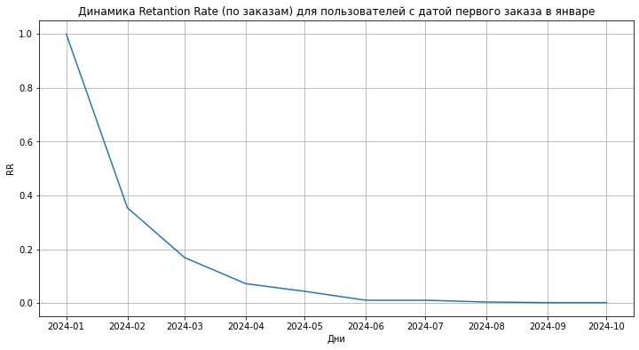

```python
# Визуализируем RR по заказам
plt.subplots(figsize=(12,6))
plt.plot(df_RR_order.index, df_RR_order.values)
plt.title('Динамика Retantion Rate (по заказам) для пользователей с датой первого заказа в январе')
plt.xlabel('Дни')
plt.ylabel('RR')
plt.grid()
plt.show()
```

**Вывод:** Показатель RR по заказам падает быстрее, чем по событиям - ко 2-му месяцу, и, в дальнейшем, практически до 0 за 8 месяцев.

### CR - конверсия в заказ

CR (Conversion Rate) в заказ = Количество пользователей, сделавших заказ/Общее количество пользователей. Считаем по месяцам.

```python
# Группируем события по месяцу события и считаем количество уникальных пользоватлеей
df_users_month = df_events.groupby('event_month')['user_id'].nunique().reset_index()
```

```python
# группируем по месяцу заказа и считаем количество уникальных пользователей, сделавших заказ
df_users_orders = df_orders.groupby('order_month')['user_id'].nunique().reset_index()
```

```python
# Объединяем данные
df_CR = pd.merge(df_users_month, df_users_orders, left_on='event_month', right_on = 'order_month', how='left' )
```

```python
# Считаем показатель
df_CR['CR_order'] = df_CR['user_id_y']/df_CR['user_id_x']
```

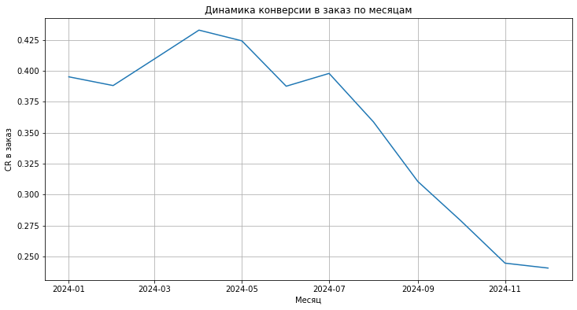

```python
# Визуализируем
plt.subplots(figsize=(12,6))
plt.plot(df_CR['order_month'], df_CR['CR_order'])
plt.title('Динамика конверсии в заказ по месяцам')
plt.xlabel('Месяц')
plt.ylabel('CR в заказ')
plt.grid()
plt.show()
```

**Вывод**: Наблюдаем падение конверсии в заказ, начиная с апреля до минимума в декабре. Что привело к снижению количества заказов, и, следовательно, к падению выручки. Необходимо проанализировать причины в продуктовой воронке.

### Средний чек AOV

Средний чек = Выручка за период/Количество продаж. Рассчитаем и визуализируем по месяцам. Используем ранее посчитанный orders_month.

```python
display(orders_month.head())
```

|  | order_month | total_price | quantity | unit_price | order_id |
| --- | --- | --- | --- | --- | --- |
| 0 | 2024-01-01 | 12977800.53 | 1918 | 6750.832728 | 964 |
| 1 | 2024-02-01 | 25931140.19 | 3851 | 6769.477846 | 1917 |
| 2 | 2024-03-01 | 38814995.89 | 5640 | 6861.186808 | 2791 |
| 3 | 2024-04-01 | 42856767.90 | 6240 | 6976.488249 | 3124 |
| 4 | 2024-05-01 | 49575162.02 | 6996 | 7092.024855 | 3518 |

```python
orders_month['AOV'] = round(orders_month['total_price']/orders_month['order_id'],2)
```

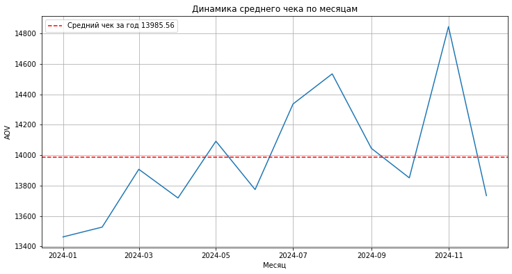

```python
# Визуализируем
plt.subplots(figsize=(12,6))
plt.plot(orders_month['order_month'], orders_month['AOV'])
plt.axhline(orders_month['AOV'].mean(), color='red', linestyle='--',
               label=f'Средний чек за год {orders_month["AOV"].mean().round(2)}')
plt.title('Динамика среднего чека по месяцам')
plt.xlabel('Месяц')
plt.ylabel('AOV')
plt.legend()
plt.grid()
plt.show()
```

**Вывод:** Значение среднего чека в течение всего года нестабильное, в диапазоне от 13400 до 14800, но резких падений вне этого диапазона - нет.

### Среднее количество товаров в заказе

Используем ранее посчитанный orders_month.

```python
orders_month['quantity_mean'] = round(orders_month['quantity']/orders_month['order_id'],2)
```

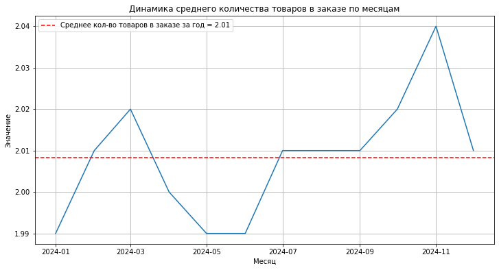

```python
# Визуализируем
plt.subplots(figsize=(12,6))
plt.plot(orders_month['order_month'], orders_month['quantity_mean'])
plt.axhline(orders_month['quantity_mean'].mean(), color='red', linestyle='--',
               label=f'Среднее кол-во товаров в заказе за год = {orders_month["quantity_mean"].mean().round(2)}')
plt.title('Динамика среднего количества товаров в заказе по месяцам')
plt.xlabel('Месяц')
plt.ylabel('Значение')
plt.legend()
plt.grid()
plt.show()
```

**Вывод:** Среднее количество товаров в корзине за год - 2, динамика без особенностей.

### Средняя цена товаров в заказе

Используем ранее посчитанный orders_month.

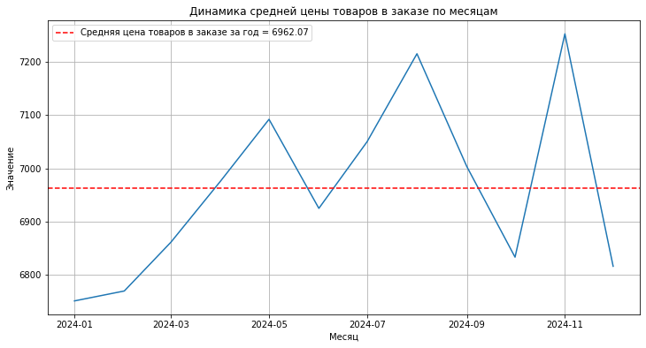

```python
# Визуализируем
plt.subplots(figsize=(12,6))
plt.plot(orders_month['order_month'], orders_month['unit_price'])
plt.axhline(orders_month['unit_price'].mean(), color='red', linestyle='--',
               label=f'Средняя цена товаров в заказе за год = {orders_month["unit_price"].mean().round(2)}')
plt.title('Динамика средней цены товаров в заказе по месяцам')
plt.xlabel('Месяц')
plt.ylabel('Значение')
plt.legend()
plt.grid()
plt.show()
```

**Вывод:** Средняя цена товара в корзине в течение всего года в диапазоне от 6700 до 7300.

### ARPU

Средняя выручка на одного пользователя (ARPU) = Вся выручка за период/Количество пользователей за период. Используем ранее посчитанный orders_month.

```python
# Считаем количество пользователей по месяцам
df_users_month = df_events.groupby('event_month')['user_id'].nunique().reset_index()
```

```python
# Объединим данные о суммах заказов за месяц с данными по количеству всех пользователей
orders_month = pd.merge(orders_month, df_users_month, left_on='order_month', right_on='event_month', how ='inner' )
```

```python
orders_month = orders_month.rename(columns = {'user_id':'users_month'})
```

```python
# Считаем показатель
orders_month['ARPU'] = round(orders_month['total_price']/orders_month['users_month'],2)
```

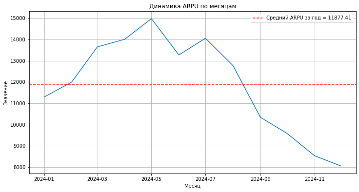

```python
# Визуализируем ARPU
plt.subplots(figsize=(12,6))
plt.plot(orders_month['order_month'], orders_month['ARPU'])
plt.axhline(orders_month['ARPU'].mean(), color='red', linestyle='--',
               label=f'Средний ARPU за год = {orders_month["ARPU"].mean().round(2)}')
plt.title('Динамика ARPU по месяцам')
plt.xlabel('Месяц')
plt.ylabel('Значение')
plt.legend()
plt.grid()
plt.show()
```

**Вывод:** Динамика ARPU демонстрирует негативные тенденции, такие же, как у выручки, конверсии в заказ: падение сначала с июня, затем с августа. Исходя из формулы показателя, можно предположить:

- уменьшилась общая выручка по месяцам, и она действительно, уменьшилась (продемонстрировано выше);
- увеличилось количество пользователей, которые ничего не покупают на маркетплейсе.

### ARPPU

Cредняя выручка от одного платящего пользователя = Вся выручка за период/Количество платящих пользователей за период.

```python
# Посчитаем количество платящих пользователей по месяцам
df_payers = df_orders.groupby('order_month')['user_id'].nunique().reset_index()
```

```python
# Объединим данные
orders_month = pd.merge(orders_month, df_payers, on='order_month', how ='inner' )
```

```python
orders_month = orders_month.rename(columns = {'user_id' : 'n_byers'})
```

```python
# Считаем показатель
orders_month['ARPPU'] = round(orders_month['total_price']/orders_month['n_byers'],2)
```

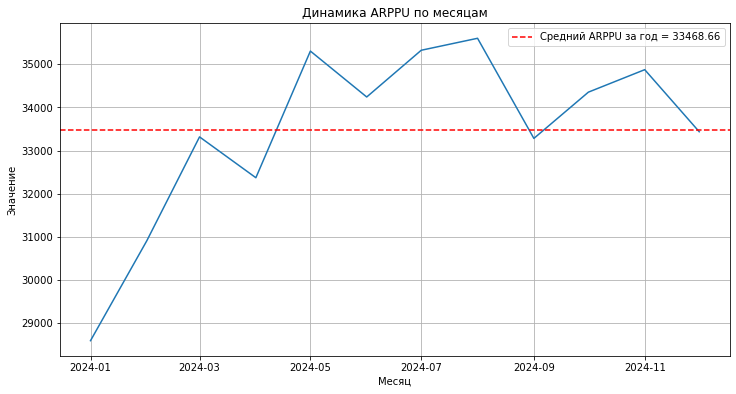

```python
# Визуализируем ARPPU
plt.subplots(figsize=(12,6))
plt.plot(orders_month['order_month'], orders_month['ARPPU'])
plt.axhline(orders_month['ARPPU'].mean(), color='red', linestyle='--',
               label=f'Средний ARPPU за год = {orders_month["ARPPU"].mean().round(2)}')
plt.title('Динамика ARPPU по месяцам')
plt.xlabel('Месяц')
plt.ylabel('Значение')
plt.legend()
plt.grid()
plt.show()
```

**Вывод:** Средняя выручка на платящего пользователя повторяет динамику среднего чека - есть и падения и рост. Значительного падения не наблюдается.

### Количество платящих пользователей

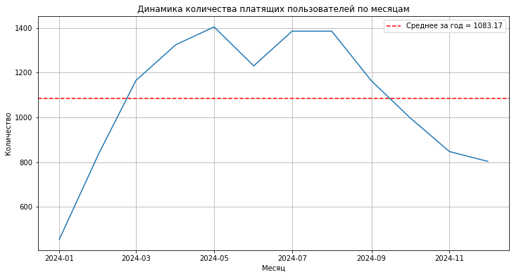

```python
# Визуализируем
plt.subplots(figsize=(12,6))
plt.plot(orders_month['order_month'], orders_month['n_byers'])
plt.axhline(orders_month['n_byers'].mean(), color='red', linestyle='--',
               label=f'Среднее за год = {orders_month["n_byers"].mean().round(2)}')
plt.title('Динамика количества платящих пользователей по месяцам')
plt.xlabel('Месяц')
plt.ylabel('Количество')
plt.legend()
plt.grid()
plt.show()
```

**Вывод:** С августа резко уменьшилось количество платящих пользователей. Необходимо проанализировать причины в продуктовой воронке.

### Ключевые метрики. Выводы

Ниже приложен слайд: красным цветом выделено негатитвное падение показателя, зеленым - рост.

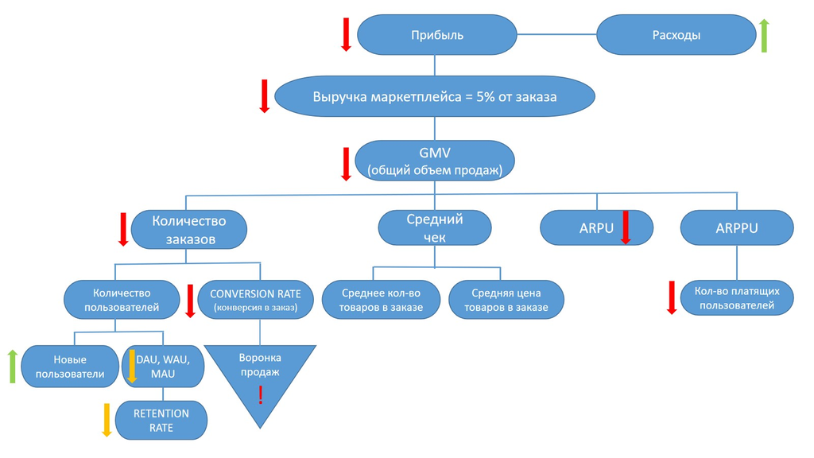

С августа бизнес демонстрирует негативные тенденции:

1. Несмотря на привлечение большого количества новых пользователей (с июля), выручка маркетплейса падает.
2. Расходы на привлечение растут.
3. Падает количество заказов, падает конверсия в повторный заказ, падает количество плательщиков.
4. Средний чек остается в течение года в диапазоне от 13400 до 14800.

## Оценка метрик монетизации и юнит-экономики

Определим, сколько зарабатывает продукт и сколько тратит на привлечение.

Рассмотрим агрегированные метрики (ARPU, AOV) и показатели эффективности (CAC, ROI, Payback Period).

### Подготовка данных

Метрики юнит-экономики считаются на платящих пользователей. Подготовим данные.

```python
# Удалим дублирующиеся строки по пользователю из заказов
df_users_payers = df_orders.drop_duplicates(subset=['user_id'], keep ='first')
```

```python
# Добавим новый столбец с признаком , что пользователь является плательщиком
df_users_payers = df_users_payers.assign(flag_payer = 1)
```

```python
# Объединим данные по пользователям с признаком оплаты
df_users = pd.merge(df_users, df_users_payers[['user_id', 'flag_payer']], on='user_id', how='left')
```

```python
df_users['flag_payer'] = df_users['flag_payer'].fillna(0)
```

```python
profiles = df_users.loc[df_users['flag_payer'] ==1]
```

```python
# Рассчитаем количество пользователей в когорте
df_users_cohort = profiles.groupby('cohort_month')['user_id'].nunique().reset_index()
```

```python
df_users_cohort = df_users_cohort.rename(columns = {'user_id' : 'N_users_cohort'})
```

```python
display(df_users_cohort.head())
```

|  | cohort_month | N_users_cohort |
| --- | --- | --- |
| 0 | 2024-01-01 | 837 |
| 1 | 2024-02-01 | 804 |
| 2 | 2024-03-01 | 877 |
| 3 | 2024-04-01 | 911 |
| 4 | 2024-05-01 | 854 |

### Средний CAC на пользователя по когортам

CAC (Customer Acquisition Cost) - стоимость привлечения клиента.

```python
# Рассчитаем количество пользователей, привлеченных в каждой рекламной кампании по дате регистрации
users_campaign = profiles.groupby(['acq_channel','cohort_month'])['user_id'].nunique().reset_index()
```

```python
# Добавим количество привлеченных в данные по кампаниям
df_campaign = pd.merge(df_campaign, users_campaign,
                       left_on=['acq_channel','spend_month'],
                       right_on=['acq_channel','cohort_month'], how='left')
```

```python
# Рассчиатем сумму, затраченную на привлечение на 1 пользователя
df_campaign['CAC'] = round(df_campaign['budget']/df_campaign['user_id'],2)
```

```python
# Добавим данные о сумме, затраченной на привлечение в Профиль пользоватлея
profiles = pd.merge(profiles, df_campaign[['acq_channel', 'cohort_month', 'CAC']],
                   on=['acq_channel','cohort_month'], how='left')
```

```python
CAC_groupped = profiles.groupby(['cohort_month'])['CAC'].mean().round(2).reset_index()
```

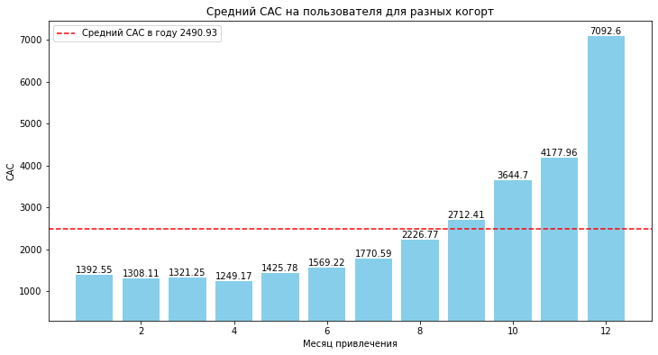

```python
# Визуализируем
plt.figure(figsize=(12,6))

bars = plt.bar(CAC_groupped['cohort_month'].dt.month, CAC_groupped['CAC'], width = 0.8, color='skyblue')
plt.ylim(300)

for bar in bars:
    yval = bar.get_height() # высота столбца=значение
    plt.text(bar.get_x() + bar.get_width()/2, yval+1, f'{yval}', verticalalignment='bottom', horizontalalignment='center')

plt.axhline(CAC_groupped['CAC'].mean(), color='red', linestyle='--',
               label=f'Средний САС в году {CAC_groupped["CAC"].mean().round(2)}')
plt.title('Средний CAC на пользователя для разных когорт')
plt.xlabel('Месяц привлечения')
plt.legend()
plt.ylabel('CAC')
plt.show()
```

**Вывод:** Стоимость привлечения покупателя растет.

### Средний LTV на пользователя по когортам

Считаем выручку маркетплейса (LTV) для когорты (месяц привлечения) и делим его на общее количество пользователей в когорте.

```python
# Рассчитаем сумму выручки от заказов на каждого пользователя
df_user_orders = df_orders.groupby('user_id')['Revenue_mp'].sum().reset_index()
```

```python
# Объединим данные , используем Профиль пользователя
df_user_orders = pd.merge(profiles, df_user_orders, on='user_id', how = 'left')
```

```python
# Группируем по когорте, считаем выручку
LTV_groupped = df_user_orders.groupby('cohort_month')['Revenue_mp'].sum().reset_index()
```

```python
# Объединяем данные с количеством пользователей в когорте
LTV_groupped = pd.merge(LTV_groupped, df_users_cohort, on='cohort_month', how='inner')
```

```python
# Считаем LTV на пользователя
LTV_groupped['LTV_mp'] = round(LTV_groupped['Revenue_mp']/LTV_groupped['N_users_cohort'],2)
```

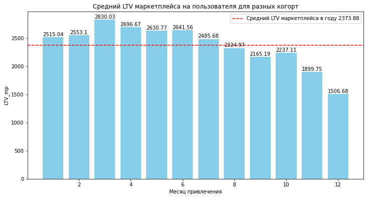

```python
# Визуализируем
plt.figure(figsize=(12,6))

bars = plt.bar(LTV_groupped['cohort_month'].dt.month, LTV_groupped['LTV_mp'], width = 0.8, color='skyblue')

for bar in bars:
    yval = bar.get_height() # высота столбца=значение
    plt.text(bar.get_x() + bar.get_width()/2, yval+1, f'{yval}', verticalalignment='bottom', horizontalalignment='center')

plt.axhline(LTV_groupped['LTV_mp'].mean(), color='red', linestyle='--',
               label=f'Средний LTV маркетплейса в году {LTV_groupped["LTV_mp"].mean().round(2)}')
plt.title('Средний LTV маркетплейса на пользователя для разных когорт')
plt.legend()
plt.xlabel('Месяц привлечения')
plt.ylabel('LTV_mp')
plt.show()
```

**Вывод:** Наблюдаем уменьшение LTV на пользователя, начиная с когорты августа. Показатель падает ниже среднего за год, достигая минимума для когорты декабря.

### LTV по когортам и месяцам

Формула: Доход маркетплейса за период/Количество клиентов в когорте.

Проведем расчеты для визуализации тепловой карты LTV по месяцам заказов для разных когорт.

```python
# Посчитаем Сумму заказы по каждому пользователю за каждый месяц
df_orders_users_month = df_orders.groupby(['order_month', 'user_id']).agg({'Revenue_mp': 'sum',
                                                                           'total_price':'sum',
                                                                           'order_id' : 'count' }).reset_index()
```

```python
# Объединим данные с данными пользователя
df_orders_users_month = pd.merge(profiles, df_orders_users_month, on='user_id', how='left' )
```

```python
# Рассчитем timedelta
df_orders_users_month['N_month'] = df_orders_users_month['order_month'].dt.month - \
                                   df_orders_users_month['cohort_month'].dt.month
```

```python
df_orders_users_month = df_orders_users_month.rename(columns={'order_id' : 'N_orders'})
```

```python
LTV_cohort_month = df_orders_users_month.groupby(['cohort_month', 'N_month']).agg({'Revenue_mp' : 'sum',
                                                                                   'total_price' : 'sum',
                                                                                    'N_orders': 'sum'}).reset_index()
```

```python
# Присединим данные о количестве пользователей в когорте
LTV_cohort_month = pd.merge(LTV_cohort_month, df_users_cohort, on='cohort_month', how='inner')
```

```python
LTV_cohort_month['LTV_mp'] = LTV_cohort_month['Revenue_mp']/LTV_cohort_month['N_users_cohort']
```

```python
# Пивотируем данные, чтобы cohort_month был индексом, а N_month — столбцом
df_pivot = LTV_cohort_month.pivot(index='cohort_month', columns='N_month', values='LTV_mp')
```

```python
# Для визуализации индекса тепловой карты в нужном виде
df_pivot = df_pivot.reset_index()
df_pivot['cohort_month'] = df_pivot['cohort_month'].dt.date
df_pivot = df_pivot.set_index('cohort_month')
```

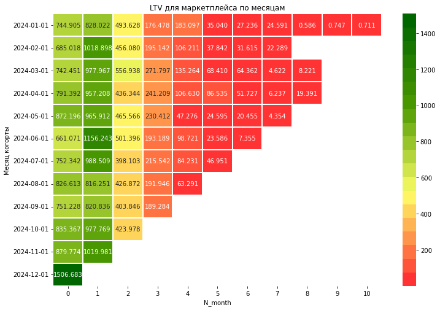

```python
# Построим heatmap
cmap = mcolors.LinearSegmentedColormap.from_list('green_red', ['#FF3333', '#FFFF66', '#4C9900', '#006600'], N=20)
plt.figure(figsize=(12, 8))

sns.heatmap(df_pivot,
          cmap=cmap,
          annot=True,
          fmt='.3f',
          linewidths=2,
          annot_kws={"size": 10})


plt.title('LTV для маркетплейса по месяцам')
plt.xlabel('N_month')
plt.ylabel('Месяц когорты')
plt.show()
```

### Накопленный LTV по когортам и месяцам

```python
# Отсортируем
LTV_cohort_month = LTV_cohort_month.sort_values(by=['cohort_month','N_month'])
```

```python
LTV_cohort_month['LTV_cum'] = round(LTV_cohort_month.groupby('cohort_month')['LTV_mp'].cumsum(),2)
```

```python
# Пивотируем данные, чтобы cohort_month был индексом, а N_month — столбцом
df_pivot = LTV_cohort_month.pivot(index='cohort_month', columns='N_month', values='LTV_cum')
```

```python
# Для визуализации индекса тепловой карты в нужном виде
df_pivot = df_pivot.reset_index()
df_pivot['cohort_month'] = df_pivot['cohort_month'].dt.date
df_pivot = df_pivot.set_index('cohort_month')
```

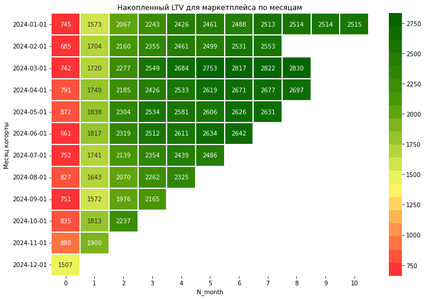

```python
# Построим heatmap
cmap = mcolors.LinearSegmentedColormap.from_list('green_red', ['#FF3333', '#FFFF66', '#4C9900', '#006600'], N=20)
plt.figure(figsize=(12, 8))

sns.heatmap(df_pivot,
          cmap=cmap,
          annot=True,
          fmt='.0f',
          linewidths=2,
          annot_kws={"size": 10})


plt.title('Накопленный LTV для маркетплейса по месяцам')
plt.xlabel('N_month')
plt.ylabel('Месяц когорты')
plt.show()
```

### ROI по когортам

```python
# Присоединим данные о стоимости привлечения клиента
LTV_CAC_cohort_month = pd.merge(LTV_cohort_month, CAC_groupped, on='cohort_month', how='inner' )
```

```python
# Считаем показатель
LTV_CAC_cohort_month['ROI'] = 100 *(LTV_CAC_cohort_month['LTV_cum'] - \
                                    LTV_CAC_cohort_month['CAC'])/LTV_CAC_cohort_month['CAC']
```

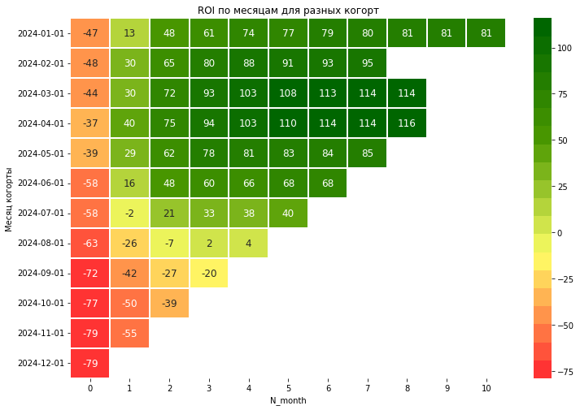

```python
#Визуализируем тепловую карту показателя ROI
# Пивотируем данные, чтобы first_week был индексом, а N_week — столбцом
df_pivot = LTV_CAC_cohort_month.pivot(index='cohort_month', columns='N_month', values='ROI')

df_pivot.index = pd.to_datetime(df_pivot.index).strftime('%Y-%m-%d')

df_pivot[df_pivot == 0] = float('nan')
plt.figure(figsize=(12, 8))

sns.heatmap(df_pivot,
            cmap=cmap,
            annot=True,
            fmt='.0f',
            linewidths=2,
            annot_kws={"size": 12})

plt.title(f'ROI по месяцам для разных когорт')
plt.xlabel('N_month')
plt.ylabel('Месяц когорты')
plt.show()
```

### AOV для когорт

Рассчитаем агрегированный средний чек для когорт. Используем LTV_cohort_month

```python
df_AOV_groupped = LTV_cohort_month.groupby('cohort_month').agg({'total_price' : 'sum',
                                                                'N_orders' : 'sum'}).reset_index()
```

```python
df_AOV_groupped['AOV'] = round(df_AOV_groupped['total_price']/df_AOV_groupped['N_orders'],2)
```

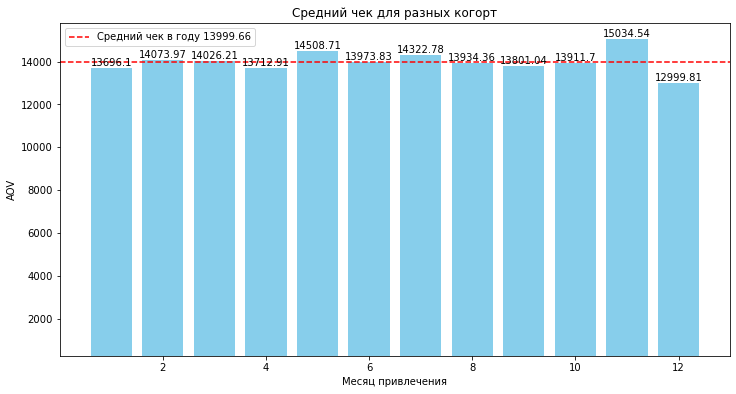

```python
# Визуализируем
plt.figure(figsize=(12, 6))

bars = plt.bar(df_AOV_groupped['cohort_month'].dt.month, df_AOV_groupped['AOV'], width = 0.8, color='skyblue')
plt.ylim(300)

for bar in bars:
    yval = bar.get_height() # высота столбца=значение
    plt.text(bar.get_x() + bar.get_width()/2, yval+1, f'{yval}', verticalalignment='bottom', horizontalalignment='center')


plt.axhline(df_AOV_groupped['AOV'].mean(), color='red', linestyle='--',
               label=f'Средний чек в году {df_AOV_groupped["AOV"].mean().round(2)}')
plt.title('Средний чек для разных когорт')
plt.xlabel('Месяц привлечения')
plt.legend()
plt.legend(loc='upper left')
plt.ylabel('AOV')
plt.show()
```

**Вывод:** Средний чек для разных когорт примерно на одном уровне, резких падений нет.

### ARPPU для когорт

Рассчитаем агрегированный показатель маркетплейса для когорт. Используем LTV_cohort_month.

```python
df_ARPPU_groupped = LTV_cohort_month.groupby('cohort_month')['Revenue_mp'].sum().reset_index()
```

```python
# Объединим данные с количеством пользователей когорты
df_ARPPU_groupped = pd.merge(df_ARPPU_groupped, df_users_cohort, on='cohort_month', how='inner')
```

```python
# Считаем показатель
df_ARPPU_groupped['ARPPU'] = round(df_ARPPU_groupped['Revenue_mp']/df_ARPPU_groupped['N_users_cohort'],2)
```

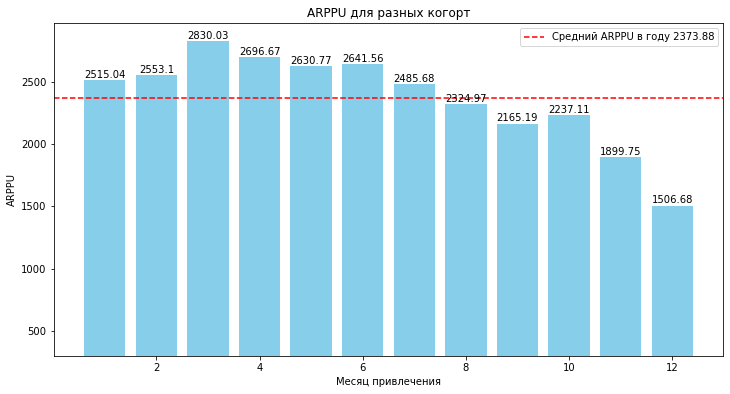

```python
# Визуализируем
plt.figure(figsize=(12, 6))

bars = plt.bar(df_ARPPU_groupped['cohort_month'].dt.month, df_ARPPU_groupped['ARPPU'], width = 0.8, color='skyblue')
plt.ylim(300)

for bar in bars:
    yval = bar.get_height() # высота столбца=значение
    plt.text(bar.get_x() + bar.get_width()/2, yval+1, f'{yval}', verticalalignment='bottom', horizontalalignment='center')


plt.axhline(df_ARPPU_groupped['ARPPU'].mean(), color='red', linestyle='--',
               label=f'Средний ARPPU в году {df_ARPPU_groupped["ARPPU"].mean().round(2)}')
plt.title('ARPPU для разных когорт')
plt.xlabel('Месяц привлечения')
plt.legend()
plt.legend(loc='upper right')
plt.ylabel('ARPPU')
plt.show()
```

**Вывод:** падение показателя ниже среднего за год, начиная с когорты августа.

### Payback Period

Период окупаемости Payback Period = CAC/ARPPU

```python
df_PP = pd.merge(CAC_groupped, df_ARPPU_groupped, on='cohort_month', how='inner')
```

```python
# Считаем показатель
df_PP['Payback_period'] = round(df_PP['CAC']/df_PP['ARPPU'],2)
```

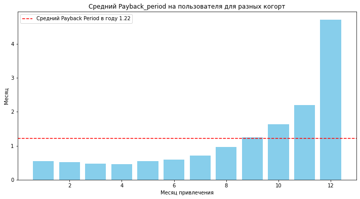

```python
# Визуализируем
plt.figure(figsize=(12, 6))

bars = plt.bar(df_PP['cohort_month'].dt.month, df_PP['Payback_period'], width = 0.8, color='skyblue')

plt.axhline(df_PP['Payback_period'].mean(), color='red', linestyle='--',
               label=f'Средний Payback Period в году {df_PP["Payback_period"].mean().round(2)}')
plt.title('Средний Payback_period на пользователя для разных когорт')
plt.xlabel('Месяц привлечения')
plt.legend()
plt.ylabel('Месяц')
plt.show()
```

**Вывод:** резкое увеличение периода окупаемости во второй половине года, начиная с августа.

### Retantion Rate по событиям и когортам

Используем users_events_month из п.5.6.

```python
# Считаем timedelta между первым заказом и последующими
users_events_month['N_month'] =  \
    (users_events_month['event_month'].dt.month - users_events_month['first_event_month'].dt.month).astype('int')
```

```python
# Агрегируем по уникальным пользователям. Там, где данных нет, проставим 0 с помощью fillna()
data_pivot_RR = pd.pivot_table(users_events_month,
                               values='user_id',
                               index='first_event_month',
                               columns='N_month',
                               aggfunc=pd.Series.nunique).fillna(0).astype(int)
```

```python
# Считаем показатель - каждое значение строки делим на значение из столбца [0]
data_pivot_RR = data_pivot_RR.div(data_pivot_RR[0], axis=0)
```

```python
display(data_pivot_RR.head())
```

| N_month first_event_month | 0 | 1 | 2 | 3 | 4 | 5 | 6 | 7 | 8 | 9 | 10 | 11 |
| --- | --- | --- | --- | --- | --- | --- | --- | --- | --- | --- | --- | --- |
| 2024-01-01 | 1.0 | 0.547433 | 0.248042 | 0.110531 | 0.055701 | 0.026110 | 0.014795 | 0.006963 | 0.000870 | 0.001741 | 0.000870 | 0.00087 |
| 2024-02-01 | 1.0 | 0.502935 | 0.213307 | 0.108284 | 0.050228 | 0.018917 | 0.009785 | 0.003262 | 0.001305 | 0.000000 | 0.000652 | 0.00000 |
| 2024-03-01 | 1.0 | 0.467562 | 0.230425 | 0.112416 | 0.054251 | 0.026846 | 0.010067 | 0.003356 | 0.001119 | 0.001678 | 0.000000 | 0.00000 |
| 2024-04-01 | 1.0 | 0.481063 | 0.232335 | 0.114189 | 0.053137 | 0.027134 | 0.013002 | 0.005653 | 0.002261 | 0.000000 | 0.000000 | 0.00000 |
| 2024-05-01 | 1.0 | 0.473308 | 0.207485 | 0.096313 | 0.042378 | 0.020363 | 0.007155 | 0.003853 | 0.000000 | 0.000000 | 0.000000 | 0.00000 |

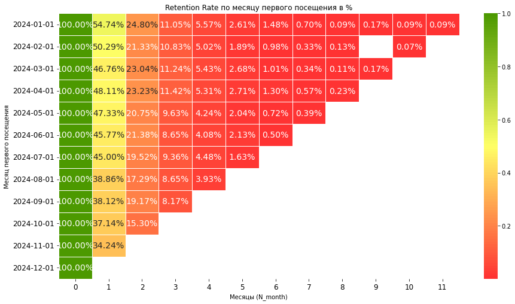

```python
# Визуализируем тепловую карту
# Для отрисовки заменяем нули на пустые значения NaN.
data_pivot_RR[data_pivot_RR == 0] = float('nan')

cmap = mcolors.LinearSegmentedColormap.from_list('green_red', ['#FF3333', '#FFFF66', '#4C9900'], N=100)

# Для корректного отображения индекса приведём его к типу ('%Y-%m-%d')
data_pivot_RR.index = pd.to_datetime(data_pivot_RR.index).strftime('%Y-%m-%d')

plt.subplots(figsize=(15,8))
sns.heatmap(data_pivot_RR,
            cmap=cmap,
            annot=True,
            fmt='.2%',
            linewidth=0.5,
            annot_kws={"size": 14})

plt.title('Retention Rate по месяцу первого посещения в %')
plt.xlabel('Месяцы (N_month)')
plt.ylabel('Месяц первого посещения')
plt.yticks(rotation=0)
plt.tick_params(labelsize=12)
plt.show()
```

**Вывод:** RR по событиям демонстрирует проблемы. В начале года 50% аудитории терялась уже во втором месяце. К третьему месяцу оставалась 1/5 аудитории. С когорты августа показатели ухудшились.

### Retantion Rate по заказам и когортам

Используем users_orders_month из п. 5.7.

```python
# Считаем timedelta между первым заказом и последующими
users_orders_month['N_month'] =  \
    (users_orders_month['order_month'].dt.month - users_orders_month['first_order_month'].dt.month).astype('int')
```

```python
# Агрегируем по уникальным пользователям. Там, где данных нет, проставим 0 с помощью fillna()
data_pivot_RR = pd.pivot_table(users_orders_month,
                               values='user_id',
                               index='first_order_month',
                               columns='N_month',
                               aggfunc=pd.Series.nunique).fillna(0).astype(int)
```

```python
# Считаем показатель - каждое значение строки делим на значение из столбца [0]
data_pivot_RR = data_pivot_RR.div(data_pivot_RR[0], axis=0)
```

```python
display(data_pivot_RR.head(12))
```

| N_month first_order_month | 0 | 1 | 2 | 3 | 4 | 5 | 6 | 7 | 8 | 9 |
| --- | --- | --- | --- | --- | --- | --- | --- | --- | --- | --- |
| 2024-01-01 | 1.0 | 0.354626 | 0.169604 | 0.072687 | 0.044053 | 0.011013 | 0.011013 | 0.004405 | 0.002203 | 0.002203 |
| 2024-02-01 | 1.0 | 0.306785 | 0.137168 | 0.056047 | 0.030973 | 0.017699 | 0.004425 | 0.000000 | 0.000000 | 0.000000 |
| 2024-03-01 | 1.0 | 0.309091 | 0.173864 | 0.080682 | 0.045455 | 0.020455 | 0.007955 | 0.001136 | 0.001136 | 0.000000 |
| 2024-04-01 | 1.0 | 0.284017 | 0.139309 | 0.055076 | 0.035637 | 0.017279 | 0.009719 | 0.003240 | 0.003240 | 0.000000 |
| 2024-05-01 | 1.0 | 0.293548 | 0.143011 | 0.070968 | 0.018280 | 0.012903 | 0.006452 | 0.002151 | 0.000000 | 0.000000 |
| 2024-06-01 | 1.0 | 0.287278 | 0.134063 | 0.058824 | 0.023256 | 0.008208 | 0.004104 | 0.000000 | 0.000000 | 0.000000 |
| 2024-07-01 | 1.0 | 0.275161 | 0.120985 | 0.056745 | 0.016060 | 0.012848 | 0.000000 | 0.000000 | 0.000000 | 0.000000 |
| 2024-08-01 | 1.0 | 0.240088 | 0.118943 | 0.053965 | 0.019824 | 0.000000 | 0.000000 | 0.000000 | 0.000000 | 0.000000 |
| 2024-09-01 | 1.0 | 0.227273 | 0.093583 | 0.041444 | 0.000000 | 0.000000 | 0.000000 | 0.000000 | 0.000000 | 0.000000 |
| 2024-10-01 | 1.0 | 0.234076 | 0.117834 | 0.000000 | 0.000000 | 0.000000 | 0.000000 | 0.000000 | 0.000000 | 0.000000 |
| 2024-11-01 | 1.0 | 0.190909 | 0.000000 | 0.000000 | 0.000000 | 0.000000 | 0.000000 | 0.000000 | 0.000000 | 0.000000 |
| 2024-12-01 | 1.0 | 0.000000 | 0.000000 | 0.000000 | 0.000000 | 0.000000 | 0.000000 | 0.000000 | 0.000000 | 0.000000 |

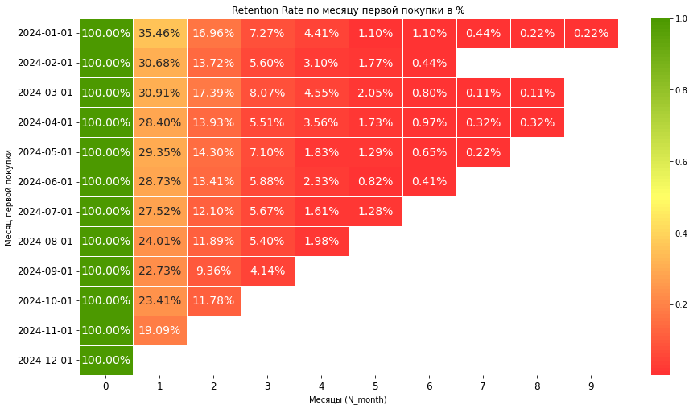

```python
# Визуализируем тепловую карту
# Для отрисовки заменяем нули на пустые значения NaN.
data_pivot_RR[data_pivot_RR == 0] = float('nan')

cmap = mcolors.LinearSegmentedColormap.from_list('green_red', ['#FF3333', '#FFFF66', '#4C9900'], N=100)

# Для корректного отображения индекса приведём его к типу ('%Y-%m-%d')
data_pivot_RR.index = pd.to_datetime(data_pivot_RR.index).strftime('%Y-%m-%d')

plt.subplots(figsize=(15,8))
sns.heatmap(data_pivot_RR,
            cmap=cmap,
            annot=True,
            fmt='.2%',
            linewidth=0.5,
            annot_kws={"size": 14})

plt.title('Retention Rate по месяцу первой покупки в %')
plt.xlabel('Месяцы (N_month)')
plt.ylabel('Месяц первой покупки')
plt.yticks(rotation=0)
plt.tick_params(labelsize=12)
plt.show()
```

**Вывод:** Интерес покупателей к повторным покупкам на маркетплейсе падает уже со второго месяца, после совершения первой покупки - до 35%-19%. Такая закономерность характерна в течение всего года, что говорит о негативной тенденции. За полгода практически полностью теряется интерес к покупкам. Показатель значительно ухудшился с когорты августа.

## Предварительные выводы на основе оценки ключевых метрик и метрик юнит-экономики

Рекомендация для дальнейшего анализа: проверить причины снижения конверсии в заказ в воронке продаж для каналов привлечения.

## Поиск инсайтов, точек роста и сегментация

С августа выручка начала резко снижаться. Проанализируем : верно ли, что снижение актуально для трёх признаков сегментации:

- acq_channel (Канал привлечения)
- region (Регион)
- buyer_segment (Сегмент покупателя)

Если окажется, что в некоторых сегментах снижение не наблюдалось, их можно будет исключить из дальнейшего анализа.

### Общее количество всех событий

Чтобы проанализировать воронку продаж, изучим события в df_events.

```python
# Получаем список всех событий
event_list = df_events['event_type'].unique()
```

```python
# Считаем количество событий в каждом месяце
events_count= df_events.groupby(['event_type','event_month'])['event_id'].count().reset_index()
```

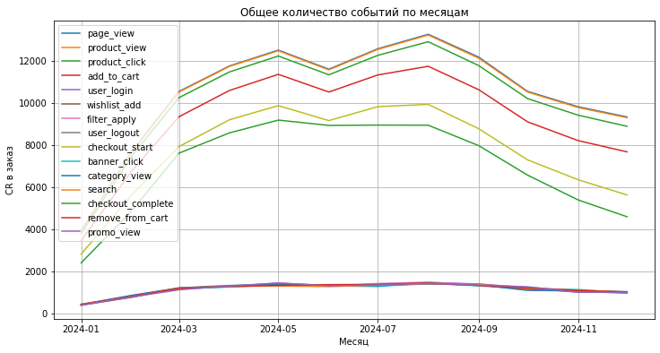

```python
# Визуализируем
plt.subplots(figsize=(12,6))
for event in event_list:
    df_plot=events_count.loc[events_count['event_type'] == event]
    plt.plot(df_plot['event_month'], df_plot['event_id'], label=event)
plt.title('Общее количество событий по месяцам')
plt.legend(loc='upper left')
plt.xlabel('Месяц')
plt.ylabel('CR в заказ')
plt.grid()
plt.show()
```

**Вывод:** Исходя из графика для анализа продуктовой воронки, нас интересуют события в следующей последовательности: 'page_view', 'product_view', 'product_click', 'add_to_cart', 'checkout_start', 'checkout_complete'.

### Анализ классической воронки

```python
# Задаем порядок шагов в воронке
funnel_steps = ['page_view','product_view','product_click','add_to_cart', 'checkout_start', 'checkout_complete']
```

```python
# Считаем число уникальных пользователей на каждом шаге
funnel_counts = df_events.groupby('event_type')['user_id'].nunique().reindex(funnel_steps)
```

```python
# Собираем таблицу воронки
funnel_df = pd.DataFrame({
   'step': pd.Series(funnel_counts.index),
   'users': pd.Series(funnel_counts.values)})
```

```python
# Добавляем конверсии и округляем до 1 знака после запятой
funnel_df['conversion_from_first_%'] = round((funnel_df['users'] / funnel_df['users'].iloc[0]) *100, 1)
```

```python
display(funnel_df.head(6))
```

|  | step | users | conversion_from_first_% |
| --- | --- | --- | --- |
| 0 | page_view | 22098 | 100.0 |
| 1 | product_view | 22069 | 99.9 |
| 2 | product_click | 21745 | 98.4 |
| 3 | add_to_cart | 20411 | 92.4 |
| 4 | checkout_start | 16769 | 75.9 |
| 5 | checkout_complete | 13897 | 62.9 |

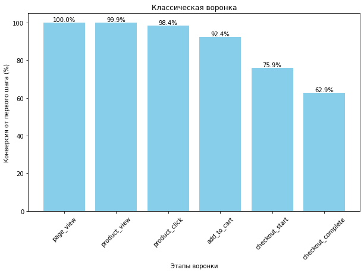

```python
# Визуализируем классическую воронку
plt.figure(figsize=(10, 6))

bars = plt.bar(funnel_df['step'], funnel_df['conversion_from_first_%'], color='skyblue')

for bar in bars:
    yval = bar.get_height() # высота столбца=значение
    plt.text(bar.get_x() + bar.get_width()/2, yval, f'{yval}%', verticalalignment='bottom', horizontalalignment='center')
    # комментарий для себя: можно также писать va= ha=

    plt.title('Классическая воронка')
plt.ylabel('Конверсия от первого шага (%)')
plt.xlabel('Этапы воронки')
plt.xticks(rotation=45)
plt.show()
```